# Functional diversity of fish communities

In D16, poor water quality brought slightly more species, and in D17 the species lost with each pressure shared traits (cold-water, flowing-water, intolerant species). A gain of species can thus hide a loss of functions, if the species gained are functionally similar and those lost are specialists [REF: Mouillot et al. 2013, doi:10.1016/j.tree.2012.10.004] [REF: Villéger et al. 2010, doi:10.1890/09-1310.1]. Here we measure the functional diversity of each community and ask whether it decreases with the pressures at equal species richness.

Steps: (1) choose the traits, (2) build a functional space, (3) measure the functional richness and dispersion of each community and compare them with a null model at equal richness, (4) relate them to dams and water quality.

## Setup

```r
library(renv)
renv::load()
```

```
- The project is out-of-sync -- use `renv::status()` for details.
```

```r
library(targets)
library(here)
tar_config_set(
  store = here::here("_targets")
)
library(ggplot2)
library(dplyr)
devtools::load_all()
nice_theme()
```

```r
colour_group <- c(
  Diet = "#009E73", Habitat = "#0072B2", `Size and life history` = "#E69F00",
  Reproduction = "#CC79A7", Morphology = "#56B4E9"
)
colour_effect <- c(Positive = "#2166AC", `Not credible` = "grey70", Negative = "#B2182B")
pressure_label <- c(
  ammonium = "Ammonium", orthophosphate = "Orthophosphate",
  oxygen_saturation = "Oxygen saturation", temperature = "Water temperature",
  accumulation = "Dams to the sea", dam_below = "Dam just downstream",
  dam_above = "Dam just upstream"
)
# Terms of the D18 models: phosphorus and oxygen are left out, as part of the
# same pollution syndrome as ammonium.
model_label <- pressure_label[c("ammonium", "temperature", "accumulation", "dam_below", "dam_above")]
```

## Traits

Functional diversity should describe what species do in the ecosystem (“effect traits”: diet, habitat use, size, reproduction, morphology) rather than how they respond to pressures (“response traits”, e.g. tolerances) [REF: Lavorel & Garnier 2002, doi:10.1046/j.1365-2435.2002.00664.x] [REF: Villéger et al. 2017, Hydrobiologia, doi to check]. We select the traits of the Dézerald et al. table (D17) with four rules:

1. **Effect traits only.** The tolerances (to water quality, oxygen, temperature, habitat degradation) and the obstacle crossing classes are excluded: they define how species respond to the pressures tested below, so including them would make the test partly circular.
2. **Complete:** known for at least 90% of the species. This drops growth rates, body sizes other than the maximum, migration distances, egg size, upper thermal tolerance, number of reproductive cycles, relative fecundity and respiration.
3. **Not redundant:** maximum length rather than maximum weight; the fuzzy diet rather than the feeding guild summarising it; the morphological ratios rather than body shape and swimming mode. Migration is left out as the trait of the dam hypotheses in D17.
4. **Equal weight per group of traits:** the distance between species is the mean of the distances of five groups, so that the nine morphological ratios do not outweigh the rest [REF: de Bello et al. 2021, doi:10.1111/2041-210X.13537].

```r
variable <- tar_read(functional_variable)
metadata <- tar_read(dezerald_metadata) |>
  distinct(trait, name)
variable |>
  mutate(
    Description = case_when(
      variable == "diet" ~ "Diet: affinity to detritus, plants and animals of three sizes (proportions)",
      variable == "living" ~ "Vertical position: bottom, near bottom, open water (fuzzy)",
      variable == "hab.RHEO" ~ "Rheophily, from still to flowing water (5 classes)",
      variable == "hab.TROPH" ~ "Feeding position: bottom or water column",
      variable == "life.LONG" ~ "Longevity",
      .default = metadata$name[match(variable, metadata$trait)]
    ),
    type = c(fuzzy = "Fuzzy", ordinal = "Ordered classes", nominal = "Categories")[type]
  ) |>
  select(Group = group, Trait = variable, Description, Type = type) |>
  knitr::kable()
```

| Group | Trait | Description | Type |
| --- | --- | --- | --- |
| Diet | diet | Diet: affinity to detritus, plants and animals of three sizes (proportions) | Fuzzy |
| Habitat | hab.RHEO | Rheophily, from still to flowing water (5 classes) | Ordered classes |
| Habitat | hab.TROPH | Feeding position: bottom or water column | Categories |
| Habitat | living | Vertical position: bottom, near bottom, open water (fuzzy) | Fuzzy |
| Size and life history | morp.LMAX | Maximum body size | Ordered classes |
| Size and life history | life.LONG | Longevity | Ordered classes |
| Size and life history | life.MAT | Maximum age of females at maturity | Ordered classes |
| Size and life history | rep.ABSFEC | Absolute fecundity | Ordered classes |
| Reproduction | rep.REPMODE | Reproductive modes | Categories |
| Reproduction | rep.REPHAB | Habitat spawning preference | Categories |
| Reproduction | rep.CARE | Parental care | Categories |
| Reproduction | rep.SPAWNMODE | Reproductive behavior | Categories |
| Morphology | morp.BLBD | Body elongation | Ordered classes |
| Morphology | morp.EHBD | Eye vertical position | Ordered classes |
| Morphology | morp.EHHD | Relative eye size | Ordered classes |
| Morphology | morp.MOBD | Oral gape position | Ordered classes |
| Morphology | morp.JLHD | Relative maxillary length | Ordered classes |
| Morphology | morp.HDBD | Body lateral shape | Ordered classes |
| Morphology | morp.PFIBD | Pectoral fin vertical position | Ordered classes |
| Morphology | morp.PFLBD | Pectoral fin size | Ordered classes |
| Morphology | morp.CFDCPD | Caudal peduncle throttling | Ordered classes |

Each trait gives a distance between 0 (same value) and 1 (most different) for each pair of species: for categories, 0 if the species share the category and 1 otherwise; for ordered classes, the gap between the two classes divided by the full range; for fuzzy traits (affinities summing to 1, e.g. diet), half the sum of the absolute differences of the affinities. The distances are averaged within each group, then across the five groups, so that each group weighs one fifth. A trait unknown for one of the two species is skipped for that pair (target `functional_distance`).

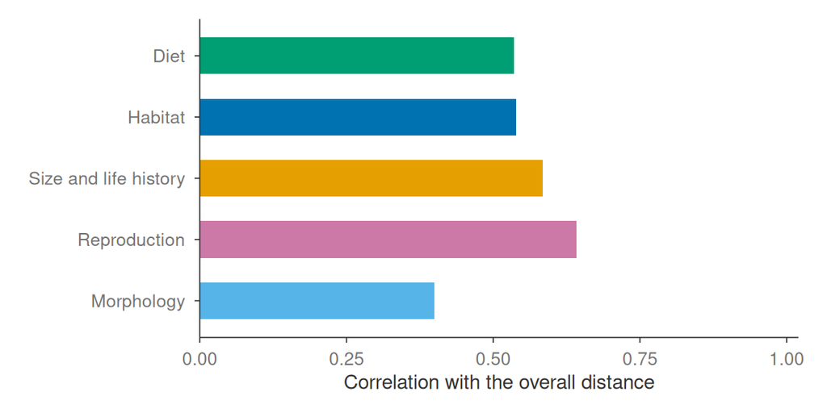

Correlation, across all pairs of species, between the distance computed from each trait group alone and the overall distance. High: the group’s differences follow the overall ranking of pairs; low: the group carries independent information.

```r
distance <- tar_read(functional_distance)
lower <- lower.tri(distance$distance)
tibble(
  group = dimnames(distance$group)[[3]],
  r = apply(distance$group, 3, \(g) cor(g[lower], distance$distance[lower]))
) |>
  mutate(group = factor(group, rev(names(colour_group)))) |>
  ggplot(aes(r, group, fill = group)) +
  geom_col(width = 0.6, show.legend = FALSE) +
  scale_fill_manual(values = colour_group) +
  scale_x_continuous(limits = c(0, 1), expand = expansion(mult = c(0, 0.02))) +
  labs(x = "Correlation with the overall distance", y = NULL) +
  theme(panel.grid.major.y = element_blank())
```

**Results:**

- Reproduction is the group most aligned with the overall distance; morphology the least, so it adds information that the other groups do not carry.

## Functional space

The species are placed in a space whose axes are those of a principal coordinate analysis of the distance. The number of axes is chosen by how well the distances in the space match the original distances (mean absolute deviation) [REF: Maire et al. 2015, doi:10.1111/geb.12299], using mFD [REF: Magneville et al. 2022, doi:10.1111/ecog.05904].

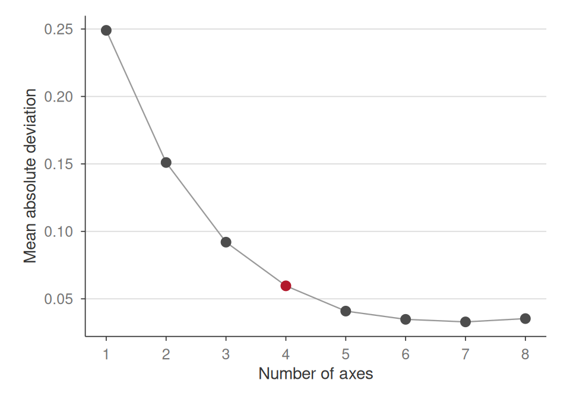

Quality of the functional space: mean absolute deviation between the distances in the space and the trait distances (lower is better).

```r
space <- tar_read(functional_space)
axis_number <- tar_read(functional_axis_number)
space$quality_fspaces |>
  tibble::rownames_to_column("space") |>
  mutate(axes = as.integer(sub("pcoa_(\\d+)d", "\\1", space))) |>
  ggplot(aes(axes, mad)) +
  geom_line(color = "grey60", linewidth = 0.4) +
  geom_point(aes(color = axes == axis_number), size = 2.5, show.legend = FALSE) +
  scale_color_manual(values = c(`TRUE` = "#B2182B", `FALSE` = "grey30")) +
  scale_x_continuous(breaks = 1:8) +
  labs(x = "Number of axes", y = "Mean absolute deviation")
```

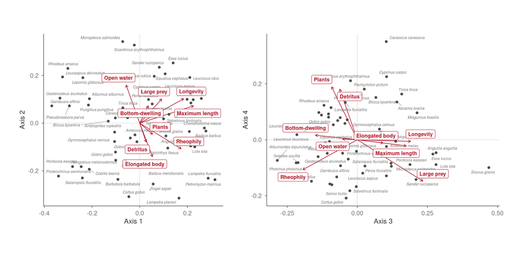

Species in the functional space (first four axes). Arrows: correlation of selected traits with the axes.

```r
coord <- tar_read(functional_coord)
trait <- tar_read(functional_trait)
species_coord <- as_tibble(coord, rownames = "species")
loading_trait <- c(
  "Rheophily" = "hab.RHEO", "Maximum length" = "morp.LMAX", "Longevity" = "life.LONG",
  "Large prey" = "diet.ANI9", "Plants" = "diet.PLANT4", "Detritus" = "diet.DET1",
  "Bottom-dwelling" = "living.BENT", "Open water" = "living.PEL", "Elongated body" = "morp.BLBD"
)
loading <- cor(coord, trait[match(rownames(coord), trait$species), loading_trait], use = "pairwise") |>
  t() |>
  as_tibble() |>
  mutate(trait = names(loading_trait))
plot_plane <- function(x, y) {
  scale <- 0.8 * max(abs(coord[, c(x, y)]))
  ggplot(species_coord, aes(.data[[x]], .data[[y]])) +
    geom_hline(yintercept = 0, color = "grey85", linewidth = 0.3) +
    geom_vline(xintercept = 0, color = "grey85", linewidth = 0.3) +
    geom_segment(
      aes(x = 0, y = 0, xend = scale * .data[[x]], yend = scale * .data[[y]]),
      data = loading, color = "#B2182B", linewidth = 0.4,
      arrow = arrow(length = unit(0.15, "cm"))
    ) +
    geom_point(color = "grey30", size = 1.3) +
    ggrepel::geom_text_repel(
      aes(label = species), size = 2.1, fontface = "italic", color = "grey45",
      max.overlaps = 6, segment.size = 0.2, seed = 1
    ) +
    ggrepel::geom_label_repel(
      aes(scale * .data[[x]], scale * .data[[y]], label = trait),
      data = loading, color = "#B2182B", size = 2.8, fontface = "bold",
      label.size = NA, fill = alpha("white", 0.8), min.segment.length = Inf, seed = 1
    ) +
    coord_equal() +
    labs(x = sub("PC", "Axis ", x), y = sub("PC", "Axis ", y)) +
    theme(panel.grid.major.y = element_blank())
}
patchwork::wrap_plots(plot_plane("PC1", "PC2"), plot_plane("PC3", "PC4"))
```

**Results:**

- Four axes represent the distances well (mean absolute deviation 0.06, below the usual threshold of 0.1).
- Axis 1 runs from small still-water species (mosquitofish, stickleback, bitterling) to large, long-lived, flowing-water and migratory species (salmon, barbel, lampreys).
- Axis 2 runs from bottom-dwellers (sculpin, brook lamprey, stone loach) to open-water predators (pike, largemouth bass, rudd).
- Axes 3 and 4 separate large-prey eaters from plant and detritus eaters.

## Functional diversity of the communities

Two indices are computed at each visit (target `functional_diversity`), on presence (each species counts once):

- **functional richness**: the volume of the space filled by the species of the community, relative to the volume of all species [REF: Villéger et al. 2008, doi:10.1890/07-1206.1]; it needs more species than axes, so visits with 4 species or fewer are left out;
- **functional dispersion**: the mean distance of the species to the centre of the community [REF: Laliberté & Legendre 2010, doi:10.1890/08-2244.1], defined for any number of species.

Both increase with the number of species. To compare communities at equal richness, the observed index is compared with 199 communities with the same species but with the traits shuffled among species (target `functional_null`), which keeps the richness of each community and the frequency of each species. The standardised effect size (SES) is the observed value minus the mean of the null values, divided by their standard deviation: negative when the species are functionally more similar than expected by chance [REF: Mouchet et al. 2010, doi:10.1111/j.1365-2435.2010.01695.x].

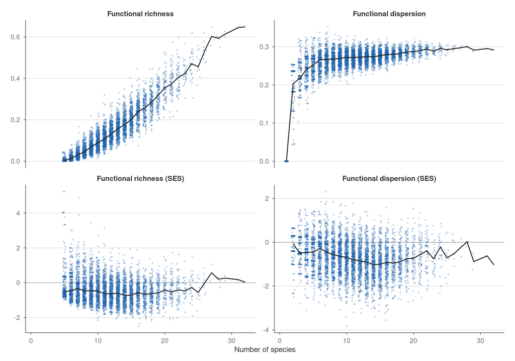

Functional richness and dispersion against species richness (top), and their standardised effect sizes (bottom). Lines: median per number of species.

```r
ses <- tar_read(functional_ses)
index_label <- c(
  fric = "Functional richness", fdis = "Functional dispersion",
  fric_ses = "Functional richness (SES)", fdis_ses = "Functional dispersion (SES)"
)
ses |>
  tidyr::pivot_longer(all_of(names(index_label)), names_to = "index") |>
  filter(is.finite(value)) |>
  mutate(index = factor(index_label[index], index_label)) |>
  ggplot(aes(richness, value)) +
  geom_hline(
    aes(yintercept = y), data = tibble(index = factor(index_label[3:4], index_label), y = 0),
    color = "grey60", linewidth = 0.3
  ) +
  geom_jitter(width = 0.25, height = 0, size = 0.4, alpha = 0.25, color = "#2166AC") +
  stat_summary(fun = median, geom = "line", color = "grey15", linewidth = 0.6) +
  facet_wrap(~index, scales = "free_y") +
  labs(x = "Number of species", y = NULL)
```

```r
ses |>
  summarise(
    across(c(fric_ses, fdis_ses), list(
      visits = \(x) sum(is.finite(x)),
      median = \(x) median(x, na.rm = TRUE),
      below = \(x) mean(x < -1.96, na.rm = TRUE),
      above = \(x) mean(x > 1.96, na.rm = TRUE)
    ))
  ) |>
  tidyr::pivot_longer(everything(), names_to = c("index", ".value"), names_pattern = "(.*_ses)_(.*)") |>
  transmute(
    Index = index_label[index], Visits = visits, `Median SES` = round(median, 2),
    `Lower than chance` = scales::percent(below, 1), `Higher than chance` = scales::percent(above, 1)
  ) |>
  knitr::kable()
```

| Index | Visits | Median SES | Lower than chance | Higher than chance |
| --- | --- | --- | --- | --- |
| Functional richness (SES) | 5203 | -0.55 | 0% | 1% |
| Functional dispersion (SES) | 5828 | -0.68 | 6% | 0% |

**Results:**

- Functional richness rises almost linearly with the number of species; functional dispersion saturates above about 8 species.
- At equal richness, most communities are slightly less diverse than expected by chance (median SES about −0.6): species that co-occur tend to share traits, as expected from environmental filtering.
- Few communities depart strongly from chance (SES beyond ±1.96).

## Dams, water quality and functional diversity

The SES of each index is modelled as the presence of species in D17 (Gaussian, same river position, sampling, site, year and spatial effects), with the three dam metrics, yearly ammonium and water temperature (target `functional_model`). Phosphorus and oxygen are left out of all the models of this notebook: they belong to the same pollution syndrome as ammonium (correlations 0.73 and −0.49), so controlling for them would remove part of the effect of pollution. Temperature is kept as a natural gradient along the river with its own effect on the fauna (D17). The ammonium effect is thus the effect of the pollution syndrome it marks. The raw indices are fitted too, for comparison.

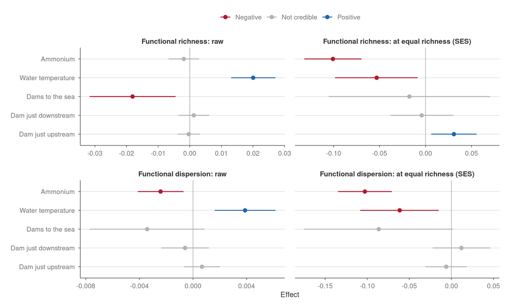

Effect of dams and pressures on functional diversity (per standard deviation of the pressure, 91% credible interval). Left: raw indices, which include the effect through species richness; right: standardised effect sizes, at equal richness.

```r
model <- tar_read(functional_model)
purrr::map_dfr(model, \(m) {
  m$summary.fixed[names(model_label), ] |>
    as_tibble(rownames = "term") |>
    transmute(response = m$response, term, mean, lower = `0.045quant`, upper = `0.955quant`)
}) |>
  mutate(
    index = factor(
      if_else(grepl("fric", response), "Functional richness", "Functional dispersion"),
      c("Functional richness", "Functional dispersion")
    ),
    scale = factor(if_else(grepl("ses", response), "at equal richness (SES)", "raw"), c("raw", "at equal richness (SES)")),
    term = factor(model_label[term], rev(model_label)),
    effect = case_when(sign(lower) != sign(upper) ~ "Not credible", mean > 0 ~ "Positive", .default = "Negative")
  ) |>
  ggplot(aes(mean, term, color = effect)) +
  geom_vline(xintercept = 0, color = "grey60", linewidth = 0.3) +
  geom_linerange(aes(xmin = lower, xmax = upper), linewidth = 0.6) +
  geom_point(size = 2.2) +
  scale_color_manual(values = colour_effect) +
  facet_wrap(index ~ scale, scales = "free_x", labeller = \(x) label_value(x, multi_line = FALSE) |> lapply(\(l) sub(",", ":", l))) +
  labs(x = "Effect", y = NULL, color = NULL) +
  theme(legend.position = "top", panel.spacing = unit(1, "lines"))
```

**Results:**

- **Ammonium** does not change the raw functional richness, but lowers both indices at equal richness: species gained with ammonium are functionally redundant, those lost are distinct. A loss of functions hidden by a stable number of species.
- **Water temperature:** warmer rivers have more species and a higher raw functional diversity, but a lower functional diversity at equal richness.
- **Dams to the sea** lower the raw functional richness (fewer species, the migratory ones), and tend to lower the dispersion at equal richness.
- **Dam just upstream** slightly raises the functional richness at equal richness; the dam just downstream has no effect.

*To discuss:*

- Presence only: abundance-weighted indices (ASPE counts) would weight the dominant species, closer to the functions of the community.
- The null model keeps the frequency of each species; a null model drawing species from the regional pool would also test the filtering of which species reach a site.
- The trait choice matters; a sensitivity analysis dropping one group at a time would show which groups drive the results.

## Which functions become redundant?

Functional diversity falls with ammonium at equal richness: the species gained are functionally similar to those already present, and those lost are distinct. Three ways to look at this more finely.

### Winners and losers in the functional space

If ammonium favours “the same kind of species”, the species it favours should cluster in one region of the functional space, and those it disfavours should lie elsewhere.

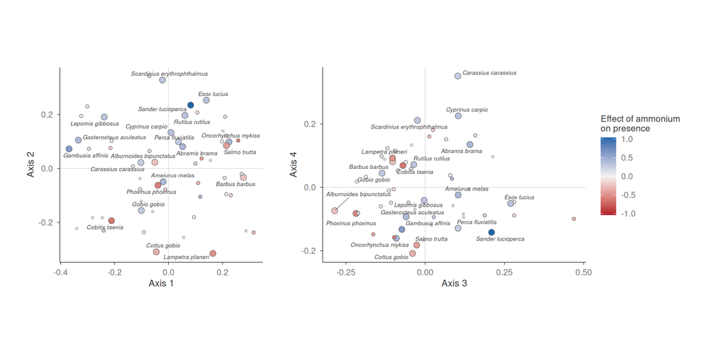

Species in the functional space (first two axes, left; axes 3 and 4, right), coloured by the effect of ammonium on their presence (D17, yearly model). Larger points: credible effects.

```r
ammonium <- tar_read(species_pressure_response) |>
  filter(term == "ammonium") |>
  mutate(credible = sign(lower) == sign(upper))
winner <- species_coord |>
  inner_join(ammonium, by = "species")
effect_limit <- max(abs(winner$mean))
plot_winner <- function(x, y) {
  ggplot(winner, aes(.data[[x]], .data[[y]])) +
    geom_hline(yintercept = 0, color = "grey85", linewidth = 0.3) +
    geom_vline(xintercept = 0, color = "grey85", linewidth = 0.3) +
    geom_point(data = anti_join(species_coord, winner, by = "species"), color = "grey80", size = 1.2) +
    geom_point(aes(fill = mean, size = credible), shape = 21, color = "grey30", stroke = 0.3) +
    ggrepel::geom_text_repel(
      aes(label = species), data = filter(winner, credible), size = 2.3, fontface = "italic",
      color = "grey25", max.overlaps = 20, segment.size = 0.2, seed = 1
    ) +
    scale_fill_gradient2(
      low = "#B2182B", mid = "grey95", high = "#2166AC", limits = c(-effect_limit, effect_limit),
      name = "Effect of ammonium\non presence"
    ) +
    scale_size_manual(values = c(`TRUE` = 3, `FALSE` = 1.6), guide = "none") +
    coord_equal() +
    labs(x = sub("PC", "Axis ", x), y = sub("PC", "Axis ", y)) +
    theme(panel.grid.major.y = element_blank(), legend.position = "right")
}
patchwork::wrap_plots(plot_winner("PC1", "PC2"), plot_winner("PC3", "PC4"), guides = "collect") &
  theme(legend.position = "right")
```

**Results:**

- Ammonium splits the functional space along axis 2: the species it favours are open-water and still-water species (pikeperch, pike, rudd, carp, roach, perch, stickleback, mosquitofish), those it disfavours are bottom-dwellers (sculpin, brook lamprey, spined loach, minnow).

### In which direction?

Lower diversity at equal richness says that species become similar, not towards which traits. The mean trait of the species present at each visit (community mean, scaled) is modelled as the functional diversity indices above (target `community_trait_model`), for size, life history and diet. Diet breadth is the Shannon diversity of the diet affinities of a species (high: generalist). Temperature is shown for contrast.

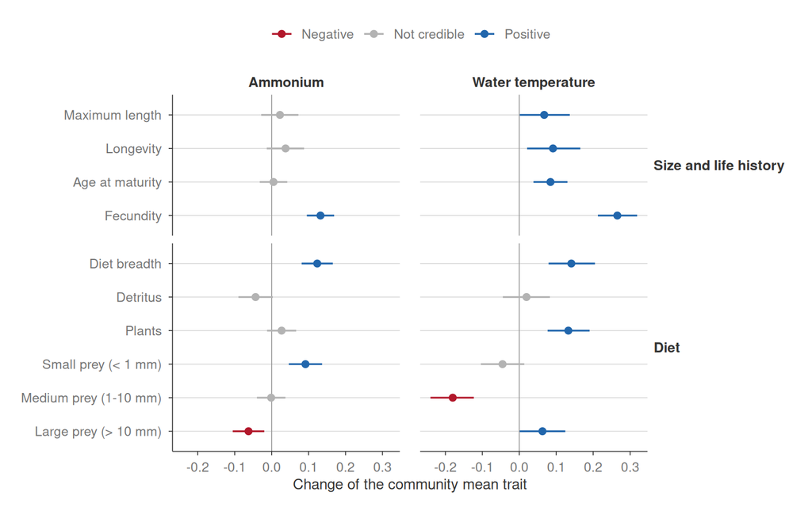

Change of the community mean trait (in standard deviations) per standard deviation of ammonium and of water temperature, 91% credible intervals.

```r
trait_direction_label <- c(
  max_length = "Maximum length", longevity = "Longevity", age_maturity = "Age at maturity",
  fecundity = "Fecundity", diet_breadth = "Diet breadth", detritus = "Detritus",
  plants = "Plants", small_prey = "Small prey (< 1 mm)", medium_prey = "Medium prey (1-10 mm)",
  large_prey = "Large prey (> 10 mm)"
)
purrr::map_dfr(tar_read(community_trait_model), \(m) {
  m$summary.fixed[c("ammonium", "temperature"), ] |>
    as_tibble(rownames = "term") |>
    transmute(term, trait = m$response, mean, lower = `0.045quant`, upper = `0.955quant`)
}) |>
  mutate(
    term = factor(pressure_label[term], pressure_label[c("ammonium", "temperature")]),
    trait = factor(trait_direction_label[trait], rev(trait_direction_label)),
    group = factor(
      if_else(trait %in% trait_direction_label[1:4], "Size and life history", "Diet"),
      c("Size and life history", "Diet")
    ),
    effect = case_when(sign(lower) != sign(upper) ~ "Not credible", mean > 0 ~ "Positive", .default = "Negative")
  ) |>
  ggplot(aes(mean, trait, color = effect)) +
  geom_vline(xintercept = 0, color = "grey60", linewidth = 0.3) +
  geom_linerange(aes(xmin = lower, xmax = upper), linewidth = 0.6) +
  geom_point(size = 2) +
  scale_color_manual(values = colour_effect) +
  facet_grid(group ~ term, scales = "free_y", space = "free_y") +
  labs(x = "Change of the community mean trait", y = NULL, color = NULL) +
  theme(legend.position = "top", panel.spacing.x = unit(1, "lines"), strip.text.y = element_text(angle = 0, hjust = 0))
```

**Results:**

- **Ammonium** shifts communities towards more fecund species with broader diets, eating more small prey and fewer large prey; size and longevity barely change on average.
- **Water temperature** shifts communities more strongly: towards larger, longer-lived, later-maturing and more fecund species with broader diets, eating more plants and fewer medium-sized invertebrates.

### Redundant species

A species is counted as redundant in a community if another species present is a near-copy of it: their functional distance is among the 5% smallest distances between the species of the pool (target `functional_redundancy`). The number of redundant species, out of the number of species, is modelled as the presence of species (binomial, same river position, sampling, site, year and spatial effects), with the local dams, the logarithm of richness (a near-copy is more likely in a richer community) and the pressure in thirds of the visits: ammonium, with temperature controlled, and water temperature, with ammonium controlled (target `redundancy_model`). Phosphorus and oxygen are left out: they are part of the same pollution syndrome as ammonium (correlations 0.73 and −0.49), so controlling for them would remove part of the effect we look for.

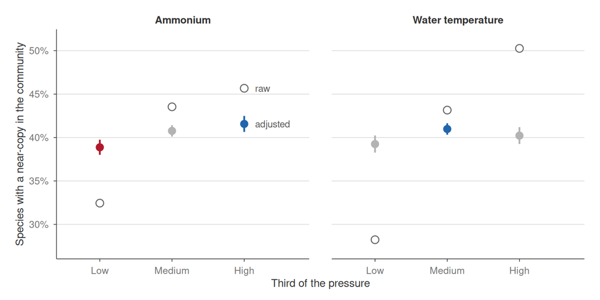

Share of the species of a community that have a near-copy in it, per third of ammonium and of water temperature. Open circles: raw mean share. Filled: share adjusted for richness, river position, sampling, dams and the other pressure (91% credible interval), centred on the raw average of the thirds. Blue: credibly above the average of the thirds; red: below.

```r
class_name <- c("Low", "Medium", "High")
redundancy_model <- tar_read(redundancy_model)
redundancy_raw <- purrr::map_dfr(redundancy_model, \(m) {
  add_pressure_class(tar_read(pressure_visit_wide), m$pressure, 3) |>
    select(operation_id, pressure_class) |>
    inner_join(
      tar_read(pressure_visit) |> filter(pressure == m$pressure) |> select(operation_id, raw = mean),
      by = "operation_id"
    ) |>
    inner_join(tar_read(functional_redundancy), by = "operation_id") |>
    summarise(
      range = if (m$pressure == "ammonium") {
        sprintf("%.2f to %.2f mg/L", 10^min(raw), 10^max(raw))
      } else {
        sprintf("%.1f to %.1f °C", min(raw), max(raw))
      },
      visits = n(),
      richness = mean(trials),
      share = mean(redundant / trials),
      .by = pressure_class
    ) |>
    arrange(pressure_class) |>
    mutate(pressure = m$pressure, class = factor(class_name, class_name))
})
redundancy_adjusted <- purrr::map_dfr(redundancy_model, \(m) {
  baseline <- mean(qlogis(redundancy_raw$share[redundancy_raw$pressure == m$pressure]))
  m$summary.lincomb.derived |>
    as_tibble(rownames = "class") |>
    transmute(
      pressure = m$pressure,
      class = factor(stringr::str_to_title(class), class_name),
      effect = case_when(`0.045quant` > 0 ~ "Positive", `0.955quant` < 0 ~ "Negative", .default = "Not credible"),
      mean = plogis(baseline + mean),
      lower = plogis(baseline + `0.045quant`),
      upper = plogis(baseline + `0.955quant`)
    )
})
redundancy_label <- bind_rows(
  filter(redundancy_raw, pressure == "ammonium", class == "High") |> transmute(pressure, class, y = share, label = "raw"),
  filter(redundancy_adjusted, pressure == "ammonium", class == "High") |> transmute(pressure, class, y = mean, label = "adjusted")
)
pressure_facet <- \(x) factor(pressure_label[x], pressure_label[c("ammonium", "temperature")])
ggplot(mutate(redundancy_adjusted, pressure = pressure_facet(pressure)), aes(class, mean)) +
  geom_point(
    aes(y = share), data = mutate(redundancy_raw, pressure = pressure_facet(pressure)),
    shape = 21, size = 3, color = "grey40", fill = "white", stroke = 0.7
  ) +
  geom_linerange(aes(ymin = lower, ymax = upper, color = effect), linewidth = 0.8) +
  geom_point(aes(color = effect), size = 3) +
  geom_text(
    aes(y = y, label = label), data = mutate(redundancy_label, pressure = pressure_facet(pressure)),
    nudge_x = 0.15, hjust = 0, size = 3.2, color = "grey35"
  ) +
  scale_color_manual(values = colour_effect, guide = "none") +
  scale_x_discrete(expand = expansion(add = c(0.6, 0.9))) +
  scale_y_continuous(labels = scales::percent_format(1), expand = expansion(mult = 0.1)) +
  facet_wrap(~pressure) +
  labs(x = "Third of the pressure", y = "Species with a near-copy in the community") +
  theme(panel.spacing.x = unit(1.5, "lines"))
```

```r
redundancy_raw |>
  transmute(
    Pressure = pressure_label[pressure], Third = class, Range = range, Visits = visits,
    `Mean number of species` = round(richness, 1),
    `Species with a near-copy (raw)` = scales::percent(share, 1)
  ) |>
  knitr::kable()
```

| Pressure | Third | Range | Visits | Mean number of species | Species with a near-copy (raw) |
| --- | --- | --- | --- | --- | --- |
| Ammonium | Low | 0.01 to 0.03 mg/L | 1802 | 9.2 | 32% |
| Ammonium | Medium | 0.03 to 0.06 mg/L | 1802 | 11.5 | 44% |
| Ammonium | High | 0.06 to 3.89 mg/L | 1802 | 11.6 | 46% |
| Water temperature | Low | 7.1 to 11.6 °C | 1802 | 7.6 | 28% |
| Water temperature | Medium | 11.6 to 12.8 °C | 1802 | 10.9 | 43% |
| Water temperature | High | 12.8 to 17.8 °C | 1802 | 13.9 | 50% |

Which are the near-copies? For each pair of near-identical species, the share of visits where both occur, in the low and in the high third of ammonium (pairs occurring together in at least 2% of the visits of either third).

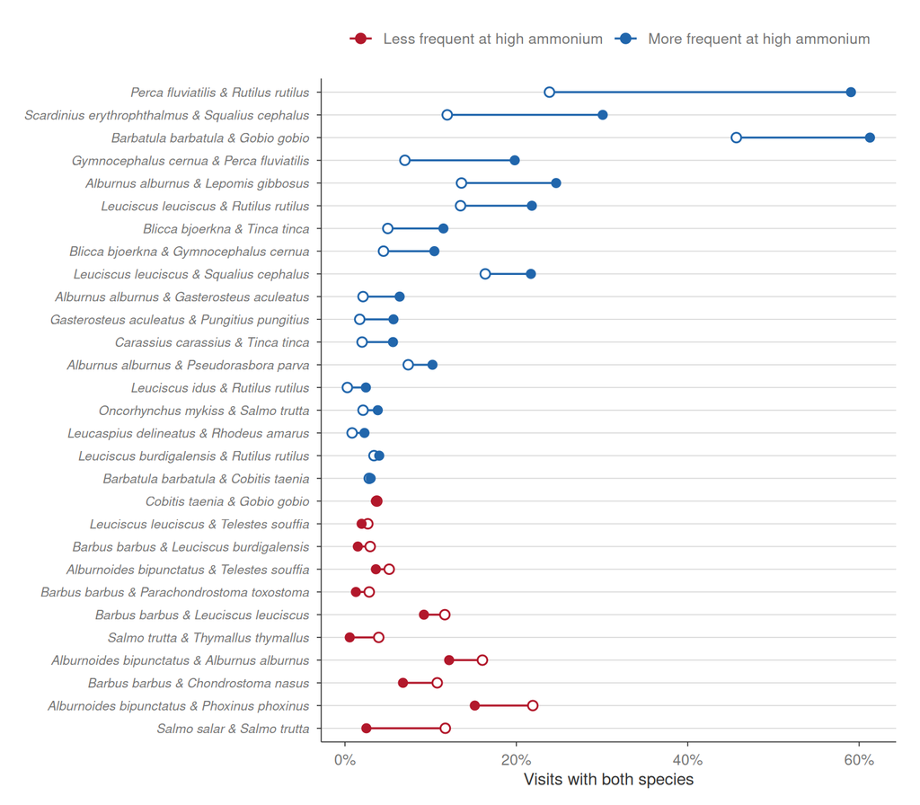

Near-identical species pairs: share of visits where both species occur, in the low (open) and high (filled) third of ammonium. Blue: more frequent at high ammonium; red: less frequent. Raw shares, not adjusted.

```r
distance <- tar_read(functional_distance)$distance
threshold <- quantile(distance[upper.tri(distance)], 0.05)
pair_index <- which(upper.tri(distance) & distance <= threshold, arr.ind = TRUE)
ammonium_third <- add_pressure_class(tar_read(pressure_visit_wide), "ammonium", 3) |>
  select(operation_id, pressure_class) |>
  filter(pressure_class %in% c(1, 3))
third_visits <- count(ammonium_third, pressure_class, name = "visits")
third_presence <- tar_read(functional_presence) |>
  inner_join(ammonium_third, by = "operation_id")
near_copy <- tibble(
  species_1 = rownames(distance)[pair_index[, 1]],
  species_2 = rownames(distance)[pair_index[, 2]]
) |>
  purrr::pmap_dfr(\(species_1, species_2) {
    inner_join(
      filter(third_presence, species == species_1),
      filter(third_presence, species == species_2),
      by = c("operation_id", "pressure_class")
    ) |>
      count(pressure_class) |>
      right_join(third_visits, by = "pressure_class") |>
      transmute(pair = paste(species_1, "&", species_2), pressure_class, share = coalesce(n, 0L) / visits)
  }) |>
  tidyr::pivot_wider(names_from = pressure_class, values_from = share, names_prefix = "third_") |>
  filter(pmax(third_1, third_3) >= 0.02) |>
  mutate(
    direction = if_else(third_3 > third_1, "More frequent at high ammonium", "Less frequent at high ammonium"),
    pair = forcats::fct_reorder(pair, third_3 - third_1)
  )
ggplot(near_copy, aes(y = pair, color = direction)) +
  geom_segment(aes(x = third_1, xend = third_3, yend = pair), linewidth = 0.6) +
  geom_point(aes(x = third_1), shape = 21, fill = "white", size = 2.3, stroke = 0.8) +
  geom_point(aes(x = third_3), size = 2.3) +
  scale_color_manual(values = c(`More frequent at high ammonium` = "#2166AC", `Less frequent at high ammonium` = "#B2182B")) +
  scale_x_continuous(labels = scales::percent_format(1)) +
  labs(x = "Visits with both species", y = NULL, color = NULL) +
  theme(axis.text.y = element_text(face = "italic", size = 8), legend.position = "top")
```

Each third is compared with the average of the three thirds (sum-to-zero coding), so that each gets its own credible interval; the adjusted shares translate these differences, estimated on the logit scale, into percentages around the raw average share.

**Results:**

## Similarity between sites

Biotic homogenisation means that communities under a pressure become more similar to each other across space [REF: Olden et al. 2004, doi:10.1016/j.tree.2003.09.010]; it often shows as a flatter distance-decay of dissimilarity: distant sites are less different than they would be without the pressure [REF: Olden & Rooney 2006, doi:10.1111/j.1466-822X.2006.00238.x]. We ask whether sites under high ammonium are more similar to each other than sites under low ammonium, and do the same for water temperature.

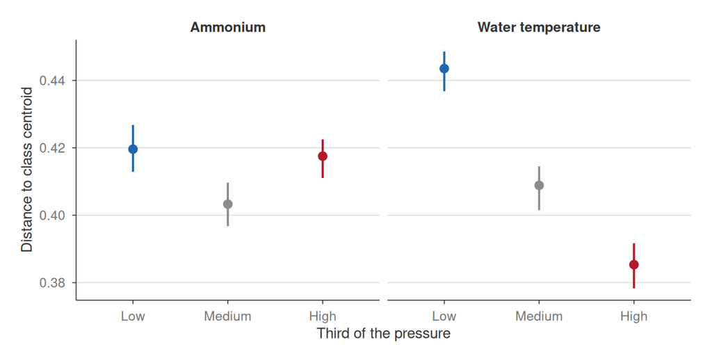

Spread of the communities of each third of the pressure around their centroid, at the same river position and other pressures (91% bootstrap interval). Lower: more homogeneous.

```r
class_label <- c(`1` = "Low", `2` = "Medium", `3` = "High")
colour_class <- c(Low = "#2166AC", Medium = "grey55", High = "#B2182B")
tar_read(class_dispersion) |>
  mutate(
    pressure = factor(pressure_label[pressure], pressure_label[c("ammonium", "temperature")]),
    class = factor(class_label[as.character(class)], class_label)
  ) |>
  ggplot(aes(class, dispersion, color = class)) +
  geom_linerange(aes(ymin = lower, ymax = upper), linewidth = 0.7) +
  geom_point(size = 2.5) +
  scale_color_manual(values = colour_class, guide = "none") +
  facet_wrap(~pressure) +
  labs(x = "Third of the pressure", y = "Distance to class centroid")
```

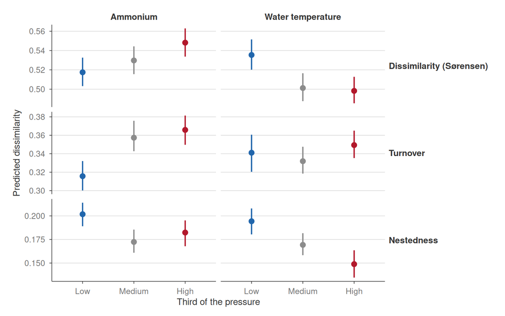

Dissimilarity between sites of the same third of the pressure, and its two components, for sites 100 km apart at the same river position and other pressures (91% bootstrap interval).

```r
response_label <- c(sorensen = "Dissimilarity (Sørensen)", turnover = "Turnover", nestedness = "Nestedness")
tar_read(class_dissimilarity_model) |>
  filter(distance == 100) |>
  summarise(
    lower = quantile(predicted[replicate > 0], 0.045),
    upper = quantile(predicted[replicate > 0], 0.955),
    predicted = predicted[replicate == 0],
    .by = c(pressure, response, class)
  ) |>
  mutate(
    pressure = factor(pressure_label[pressure], pressure_label[c("ammonium", "temperature")]),
    response = factor(response_label[response], response_label),
    class = factor(class_label[as.character(class)], class_label)
  ) |>
  ggplot(aes(class, predicted, color = class)) +
  geom_linerange(aes(ymin = lower, ymax = upper), linewidth = 0.7) +
  geom_point(size = 2.5) +
  scale_color_manual(values = colour_class, guide = "none") +
  facet_grid(response ~ pressure, scales = "free_y") +
  labs(x = "Third of the pressure", y = "Predicted dissimilarity") +
  theme(strip.text.y = element_text(angle = 0, hjust = 0))
```

At equal environment, dissimilarity barely increases with distance within 200 km (the river position, the pressures and the catchment explain most of the differences between distant sites), so the distance-decay curves are not shown.

**Results:**

- **Ammonium does not homogenise communities.** At the same river position, dams and temperature, sites of the high third are not more similar to each other than sites of the low third; they are slightly more different. Their differences come more from the replacement of species (higher turnover) and less from species-poor subsets (lower nestedness). The dispersion around the class centroid does not differ between low and high ammonium.
- **Water temperature homogenises communities.** Warm sites (medium and high thirds) are more similar to each other than cold sites, mostly through lower nestedness, and the dispersion around the centroid falls steadily from cold to warm sites, at the same river position.
- So ammonium reduces functional diversity within communities (more near-copies, previous sections) without making communities more alike across sites; warm water does make them more alike.

*To discuss:*

- One visit per site; using all visits would add the change of communities in time.
- The classes are thirds of the predicted pressure; within a class, sites still differ in pressure, especially in the highest third (long tail of ammonium).
- Taxonomic dissimilarity only; functional dissimilarity between sites would test functional homogenisation.

## Next steps

- Habitat specialisation (community specialisation index, [REF: Clavel et al. 2011, doi:10.1890/080216]): a first version (width x slope classes) ranked large-river species as specialists and trout as a generalist, because large rivers are rare and lumped in the ASPE sample and the thermal niche was left out; to redo with habitat classes on equal steps weighted by river network length, and separate structural, thermal and chemical specialisation.
- Abundance-weighted indices (ASPE counts), closer to the functions of the communities.
- Functional dissimilarity between sites, to test functional rather than taxonomic homogenisation.